# Regression Trees and Rule-Based Models

https://github.com/cran/AppliedPredictiveModeling/blob/master/inst/chapters/08_Regression_Trees.R https://www.guru99.com/r-decision-trees.html

##### Chapter 8 KJ 8.1, 8.2, 8.3, 8.7

### Problem 1

Recreate the simulated data from Exercise 7.2:

Per 7.2, Friedman (1991) introduced several benchmark data sets create by simulation. One of these simulations used the following nonlinear equation to create data:

$$y = 10 sin(πx1x2) + 20(x3 − 0.5)2 + 10x4 + 5x5 + N(0, σ2)$$
where the x values are random variables uniformly distributed between [0, 1] (there are also 5 other non-informative variables also created in the simulation).

```r
set.seed(200)
simulated <- mlbench.friedman1(200, sd = 1)
simulated <- cbind(simulated$x, simulated$y)
simulated <- as.data.frame(simulated)
colnames(simulated)[ncol(simulated)] <- "y"
```

#### (a) Fit a random forest model to all of the predictors, then estimate the variable importance scores:

```r
model1 = randomForest( y ~ ., data=simulated, importance=TRUE, ntree=1000 )
rfImp1 = varImp(model1, scale=FALSE)
rfImp1 = rfImp1[ order(-rfImp1), , drop=FALSE ]
print("randomForest (no correlated predictor)")
```

```
## [1] "randomForest (no correlated predictor)"
```

```r
print("Table 1: Variable importance scores for part (a) simulation.")
```

```
## [1] "Table 1: Variable importance scores for part (a) simulation."
```

```r
print(rfImp1)
```

```
##         Overall
## V1   8.83890885
## V4   7.58822553
## V2   6.49023056
## V5   2.27426009
## V3   0.67583163
## V6   0.17436781
## V7   0.15136583
## V9  -0.02989832
## V8  -0.03078937
## V10 -0.08529218
```

17. Did the random forest model significantly use the uninformative predictors (V6 – V10)?
18. The predictor significance for the simulated data set in this model can be seen in Table 1. The model weights predictors V1,V4,V2,V5,V3 in order of diminishing significance and trailing off after that.

##### (b) Fit another random forest model to these data. Did the importance score for V1 change? What happens when you add another predictors that is also highly correlated with V1?

```r
simulated$duplicate1 <- simulated$V1 + rnorm(200) * .1
cor(simulated$duplicate1, simulated$V1)
```

```
## [1] 0.9396216
```

After adding a highly correlated, predictors are ordered V4,V1,V2,duplicate1,V5 in order of diminishing significance and trailing off after that. V1 moved down to 2nd place in ranking.

```r
model2 = randomForest( y ~ ., data=simulated, importance=TRUE, ntree=1000 )
rfImp2 = varImp(model2, scale=FALSE)
rfImp2 = rfImp2[ order(-rfImp2), , drop=FALSE ]
print("randomForest (one correlated predictor)")
```

```
## [1] "randomForest (one correlated predictor)"
```

```r
print("Table 2: Variable importance scores for part (b) simulation.")
```

```
## [1] "Table 2: Variable importance scores for part (b) simulation."
```

```r
print(rfImp2)
```

```
##                Overall
## V4          6.93924427
## V1          6.29780744
## V2          6.08038134
## duplicate1  3.56411581
## V5          2.03104094
## V3          0.58410718
## V6          0.07947642
## V10        -0.00715093
## V7         -0.02566414
## V9         -0.08839463
## V8         -0.11007435
```

```r
simulated$duplicate2 = simulated$V1 + rnorm(200) * .1
cor(simulated$duplicate2,simulated$V1)
```

```
## [1] 0.9312569
```

```r
model3 = randomForest( y ~ ., data=simulated, importance=TRUE, ntree=1000 )
rfImp3 = varImp(model3, scale=FALSE)
rfImp3 = rfImp3[ order(-rfImp3), , drop=FALSE ]
print("randomForest (two correlated predictors)")
```

```
## [1] "randomForest (two correlated predictors)"
```

```r
print(rfImp3)
```

```
##                 Overall
## V4          7.280227792
## V2          6.957366954
## V1          5.656397024
## duplicate2  2.654958084
## duplicate1  2.566313355
## V5          2.094226861
## V3          0.539700105
## V6          0.141163232
## V7          0.092792498
## V10         0.016839393
## V9         -0.007463533
## V8         -0.096325566
```

##### c) Study this when fitting conditional inference trees:

Use the cforest function in the party package to fit a random forest model using conditional inference trees. The party package function varimp can calculate predictor importance. The conditional argument of that function toggles between the traditional importance measure and the modified version described in Strobl et al. (2007).

Do these importances show the same pattern as the traditional random forest model? Yes, the conditional inference model has a similar pattern of importance as the random forest model from Part (a). Predictor’s rank importance scores for the conditional inference random forests are shown as follows . . .

no correlated predictor V1,V4,V2,V5,V7 one correlated predictor and V4,V1,V2,duplicate1,V5 two correlated predictor V4,V1,V2,duplicate2,duplicate1

So once again, adding highly correlated predictors reduces the value other predictors and reduces the rank of V1.

```r
simulated$duplicate1 = NULL
simulated$duplicate2 = NULL

model1 = cforest( y ~ ., data=simulated )
cfImp1 = as.data.frame(varimp(model1),conditional=TRUE)
cfImp1 = cfImp1[ order(-cfImp1), , drop=FALSE ]
print(sprintf("cforest (no correlated predictor);varimp(*,conditional=%s)",TRUE))
```

```
## [1] "cforest (no correlated predictor);varimp(*,conditional=TRUE)"
```

```r
print(cfImp1)
```

```
##     varimp(model1)
## V1      8.91373010
## V4      8.32329262
## V2      6.73542178
## V5      1.90816209
## V7      0.08061713
## V3      0.04023197
## V6      0.01988075
## V8     -0.02959109
## V9     -0.03229061
## V10    -0.04345865
```

```r
# Now we add correlated predictors one at a time
simulated$duplicate1 = simulated$V1 + rnorm(200) * 0.1

model2 = cforest( y ~ ., data=simulated )
cfImp2 = as.data.frame(varimp(model2),conditional=use_conditional_true)
cfImp2 = cfImp2[ order(-cfImp2), , drop=FALSE ]
print(sprintf("cforest (one correlated predictor);varimp(*,conditional=%s)",TRUE))
```

```
## [1] "cforest (one correlated predictor);varimp(*,conditional=TRUE)"
```

```r
print(cfImp2)
```

```
##            varimp(model2)
## V4             7.74250884
## V1             7.00760188
## V2             6.47356035
## duplicate1     2.36372033
## V5             1.63267034
## V7             0.04655717
## V6            -0.01284270
## V10           -0.01809238
## V3            -0.01823753
## V9            -0.02020162
## V8            -0.05335786
```

```r
simulated$duplicate2 = simulated$V1 + rnorm(200) * 0.1

model3 = cforest( y ~ ., data=simulated )
cfImp3 = as.data.frame(varimp(model3),conditional=TRUE)
cfImp3 = cfImp3[ order(-cfImp3), , drop=FALSE ]
print(sprintf("cforest (two correlated predictor); varimp(*,conditional=%s)",TRUE))
```

```
## [1] "cforest (two correlated predictor); varimp(*,conditional=TRUE)"
```

```r
print(cfImp3)
```

```
##            varimp(model3)
## V4             6.97622560
## V1             6.16005851
## V2             5.79720094
## duplicate2     1.99221067
## duplicate1     1.75162719
## V5             1.64925601
## V9             0.04764599
## V7             0.04113817
## V3             0.02690796
## V8            -0.04482440
## V10           -0.04691707
## V6            -0.05223137
```

#### (d) Repeat this process with different tree models, such as boosted trees and Cubist.

Does the same pattern occur?

no correlated predictor V4,V1,V2,V5,V3 one correlated predictor and V4,V2,V1,duplicate1,V5 two correlated predictor V4,V2,V1,V5,V3

```r
simulated$duplicate1 = NULL
simulated$duplicate2 = NULL

model1 = gbm( y ~ ., data=simulated, distribution="gaussian", n.trees=1000 )
print(sprintf("gbm (no correlated predictor)"))
```

```
## [1] "gbm (no correlated predictor)"
```

```r
print(summary(model1,plotit=F)) # the summary method gives variable importance ...
```

```
##     var   rel.inf
## V4   V4 25.834543
## V1   V1 22.409641
## V2   V2 19.821104
## V5   V5 11.154200
## V3   V3  9.274196
## V6   V6  2.839395
## V7   V7  2.636264
## V8   V8  2.327547
## V9   V9  1.867610
## V10 V10  1.835500
```

```r
# Now we add correlated predictors one at a time
simulated$duplicate1 = simulated$V1 + rnorm(200) * 0.1

model2 = gbm( y ~ ., data=simulated, distribution="gaussian", n.trees=1000 )
print(sprintf("gbm (one correlated predictor)"))
```

```
## [1] "gbm (one correlated predictor)"
```

```r
print(summary(model2,plotit=F))
```

```
##                   var   rel.inf
## V4                 V4 24.482141
## V2                 V2 19.263836
## V1                 V1 13.959108
## duplicate1 duplicate1 11.851314
## V5                 V5 11.059253
## V3                 V3  9.058481
## V7                 V7  3.335014
## V6                 V6  2.230353
## V10               V10  1.625637
## V8                 V8  1.595524
## V9                 V9  1.539339
```

```r
simulated$duplicate2 = simulated$V1 + rnorm(200) * 0.1

model3 = gbm( y ~ ., data=simulated, distribution="gaussian", n.trees=1000 )
print(sprintf("gbm (two correlated predictor)"))
```

```
## [1] "gbm (two correlated predictor)"
```

```r
print(summary(model3,plotit=F))
```

```
##                   var   rel.inf
## V4                 V4 24.013138
## V2                 V2 19.612456
## V1                 V1 14.308784
## V5                 V5 10.711146
## V3                 V3  8.657045
## duplicate1 duplicate1  7.659392
## duplicate2 duplicate2  5.863913
## V6                 V6  2.244922
## V7                 V7  2.174548
## V8                 V8  1.699159
## V10               V10  1.578054
## V9                 V9  1.477443
```

```r
set.seed(200)
simulated1 <- mlbench.friedman1(200, sd = 1)
simulated1 <- cbind(simulated1$x, simulated1$y)
simulated1 <- as.data.frame(simulated1)
colnames(simulated1)[ncol(simulated1)] <- "y"

set.seed(200)
simulated2 <-
  simulated1 %>%
  mutate(duplicate1 = V1 + rnorm(200) * .1)

cor(simulated2$duplicate1, simulated2$V1)
```

```
## [1] 0.9497025
```

```r
# add another correlated variable
set.seed(5)
simulated3 <-
  simulated2 %>%
  mutate(duplicate2 = V1 + rnorm(200) * .1)

cor(simulated3$duplicate2, simulated3$V1)
```

```
## [1] 0.9412195
```

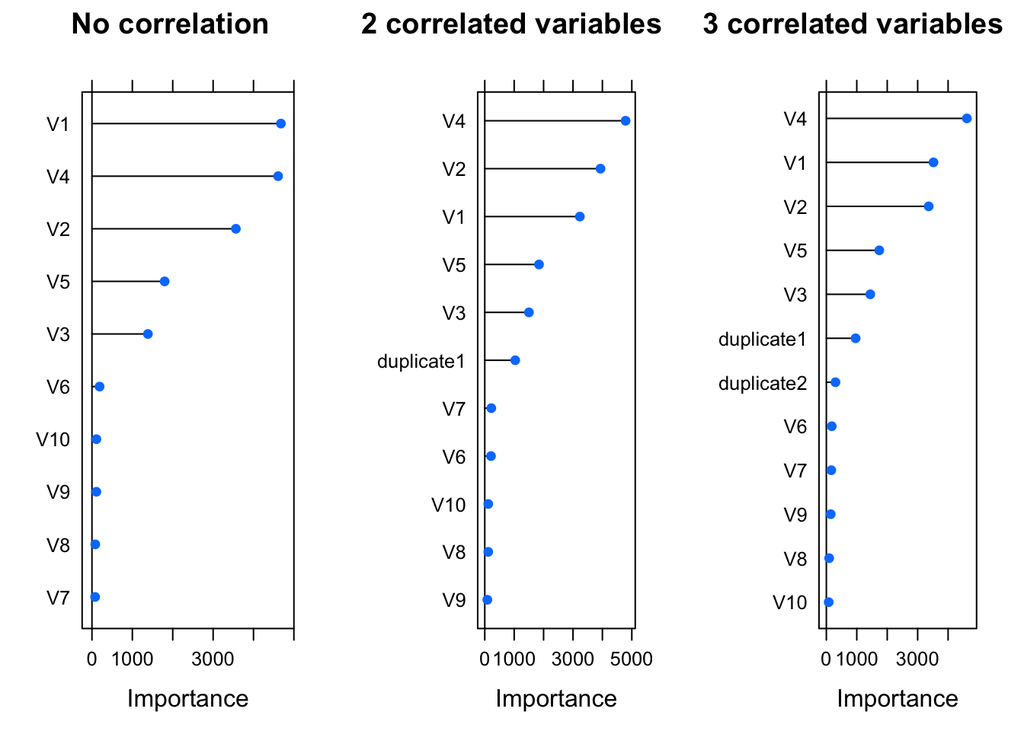

```r
gbm1 <- train(y ~ ., data = simulated1, method = "gbm", verbose = F)
gbm2 <- train(y ~ ., data = simulated2, method = "gbm", verbose = F)
gbm3 <- train(y ~ ., data = simulated3, method = "gbm", verbose = F)


gridExtra::grid.arrange(
  plot(varImp(gbm1, scale = F), main = "No correlation"),
  plot(varImp(gbm2, scale = F), main = "2 correlated variables"),
  plot(varImp(gbm3, scale = F), main = "3 correlated variables"),
  ncol = 3
)
```

```r
vnames <- c('V1', 'V2', 'V3', 'V4', 'V5', 'V6', 'V7', 'V8', 'V9', 'V10')
cbFit1 <- cubist(x = simulated[, 1:10],
                 y = simulated$y,
                 committees = 100)
cbImp1 <- varImp(cbFit1)
names(cbImp1) <- "Original"
cbImp1$Variable <- factor(rownames(cbImp1), levels = vnames)

cbFit2 <- cubist(x = simulated[, names(simulated) != "y"],
                 y = simulated$y, committees = 100)
cbImp2 <- varImp(cbFit2)
names(cbImp2) <- "Extra"

cbImp2$Variable <- factor(rownames(cbImp2), levels = vnames)
cbImp <- merge(cbImp1, cbImp2, all = TRUE)
#rownames(cbImp) <- cbImp$Variable #this won't knit, commenting out
#cbImp$Variable <- NULL
print(cbImp)
```

```
##    Variable Original Extra
## 1        V1     71.5  58.0
## 2        V2     58.5  62.0
## 3        V3     47.0  43.5
## 4        V4     48.0  42.0
## 5        V5     33.0  27.0
## 6        V6     13.0   5.5
## 7        V7      0.0   0.0
## 8        V8      0.0   1.5
## 9        V9      0.0   0.5
## 10      V10      0.0   0.0
## 11     <NA>       NA  15.0
## 12     <NA>       NA   4.5
```

### Problem 2

#### a) Use a simulation to show tree bias with different granularities.

From 8.2, . . . intuitively, predictors that appear higher in the tree (i.e., earlier splits) or those that appear multiple times in the tree will be more important than predictors that occur lower in the tree or not at all. even if the predictor has little-to-no relationship with the response.

This simulation uses one categorical predictor splitting the response into two groups. As a comparison, a similar simulation uses a continuous predictor that doesn’t split the response into two groups.

simulations where X1 is categorical and X2 is continuous

```r
X_categorical <- rep(1:2,each=100)
Y <- X_categorical + rnorm(200,mean=0,sd=4)
set.seed(103)
X_continuous <- rnorm(200,mean=0,sd=2)
simData <- data.frame(Y=Y,X_categorical=X_categorical,X_continuous=X_continuous)
```

Note predictor X1 splits the response into two response groups and predictor X2, is independent of response.

[output not shown]

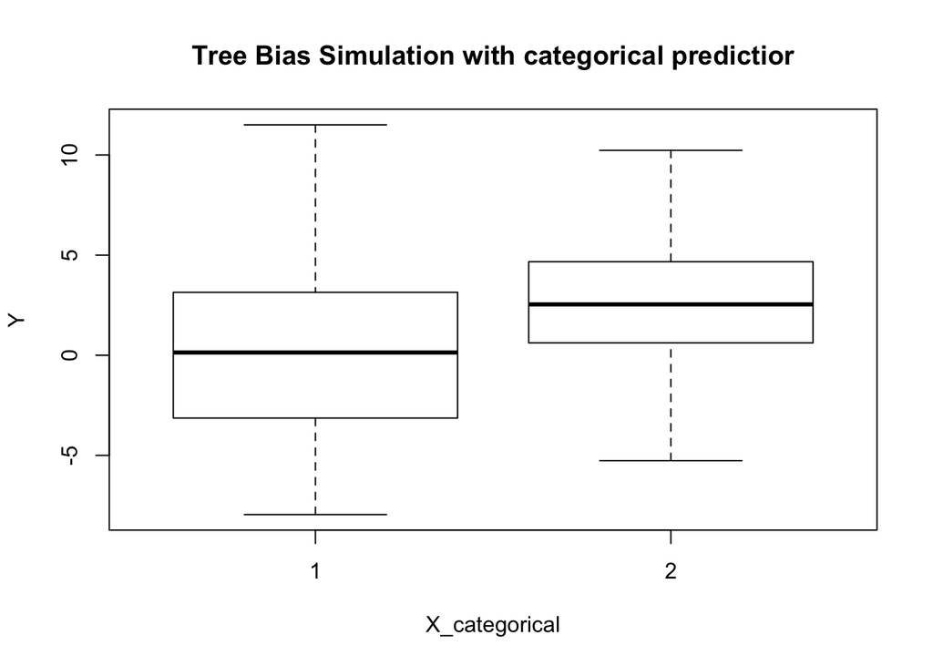

```r
boxplot(
  Y~X_categorical,
  #data=Y,
  main="Tree Bias Simulation with categorical predictior",
  xlab="X_categorical",
  ylab="Y"
)
```

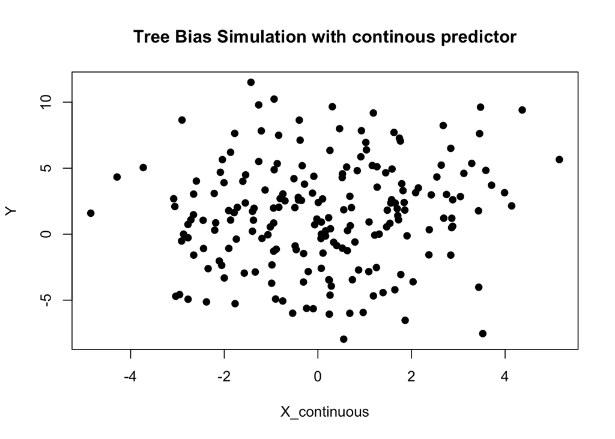

```r
plot(
  X_continuous,
  Y,
  main="Tree Bias Simulation with continous predictor",
  xlab="X_continuous",
  ylab="Y",
  pch=19
)
```

### Problem 3

In stochastic gradient boosting the bagging fraction and learning rate will govern the construction of the trees as they are guided by the gradient. Although the optimal values of these parameters should be obtained through the tuning process, it is helpful to understand how the magnitudes of these parameters affect magnitudes of variable importance.

Figure 2 provides the variable importance plots for boosting using two extreme values for the bagging fraction (0.1 and 0.9) and the learning rate (0.1 and 0.9) for the solubility data. The left-hand plot has both parameters set to 0.1, and the right-hand plot has both set to 0.9.

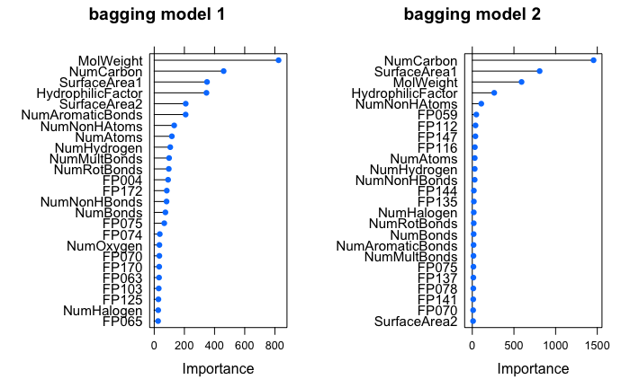

fig Bagging Models

#### (a) Why does the model on the right focus its importance on just the first few of predictors,whereas the #### model on the left spreads importance across more predictors?

[output not shown]

#### (b) Which model do you think would be more predictive of other samples?

[output not shown]

#### (c) How would increasing interaction depth affect the slope of predictor importance for either model in Figure 2?

[output not shown]

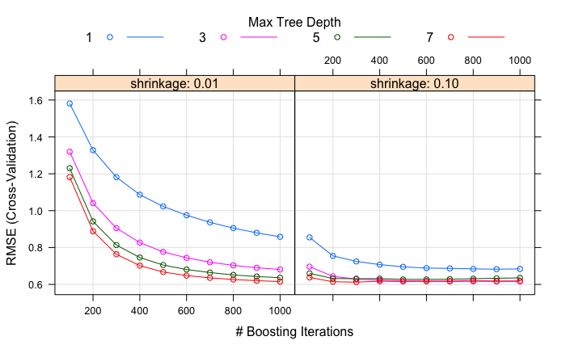

Tree Depth

### Problem 7

8.7. Refer to Exercises 6.3 and 7.5 which describe a chemical manufacturing process. Use the same data imputation, data splitting, and pre-processing steps as before and train several tree-based models:

1. Which tree-based regression model gives the optimal resampling and test set performance?
2. Which predictors are most important in the optimal tree-based regression model? Do either the biological or process variables dominate the list? How do  
   the top 10 important predictors compare to the top 10 predictors from the optimal linear and nonlinear models?
3. Plot the optimal single tree with the distribution of yield in the terminal nodes. Does this view of the data provide additional knowledge about the biological or process predictors and their relationship with yield?

#### (a) We set aside 20% of the observations to be the test dataset.

```
##           cp
## 7 0.04662091
```

```
##  model         cp     RMSE
##   CART 0.04662091 1.594938
```

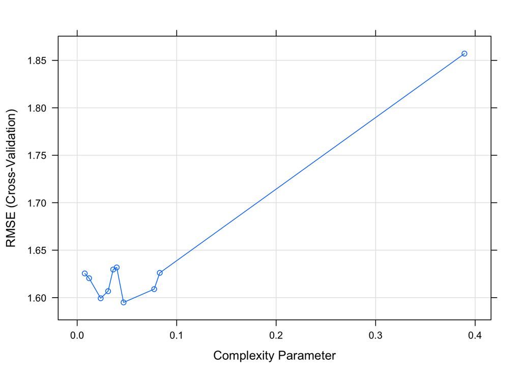

```
##        7       11       18       19       24       35       40       52
## 39.86409 41.95920 39.86409 39.86409 41.95920 39.86409 41.95920 41.95920
##       56       63       64       65       66       67       70       73
## 41.95920 39.86409 39.86409 41.95920 41.95920 41.95920 38.42333 41.95920
##       77       92       98      102      109      116      119      121
## 39.86409 38.42333 41.95920 38.42333 39.86409 39.85273 38.42333 38.42333
##      129      132      133      141      146      153      157      165
## 41.95920 39.86409 38.42333 38.42333 39.86409 38.42333 38.42333 38.42333
```

```
##   mtry
## 5   25
```

```
##         model mtry     RMSE
##  Random Fores   25 1.232087
```

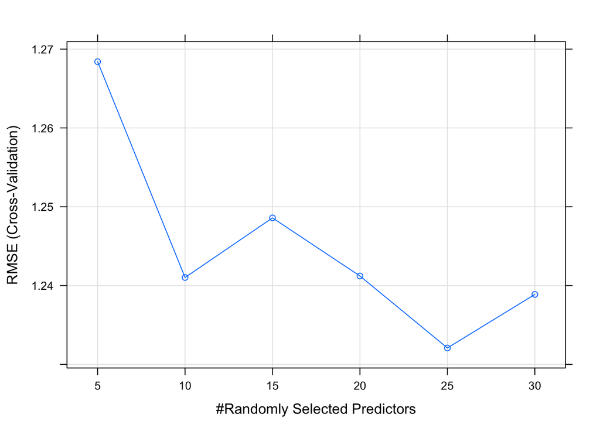

```
##        7       11       18       19       24       35       40       52
## 41.87759 42.12419 40.23719 39.89654 41.43634 39.73143 41.40566 41.69404
##       56       63       64       65       66       67       70       73
## 40.77427 39.23845 40.50917 41.08439 41.04899 40.96981 39.39426 41.18142
##       77       92       98      102      109      116      119      121
## 39.75830 39.55553 40.20488 38.14871 39.37605 40.91471 38.77659 38.83168
##      129      132      133      141      146      153      157      165
## 41.14619 40.00528 38.92066 38.33799 38.99763 38.28808 38.04452 39.42322
```

```
##    nrounds max_depth eta gamma colsample_bytree min_child_weight subsample
## 29     250        10 0.1     0             0.25                0         1
```

```
##              model nrounds max_depth eta gamma colsample_bytree
##  Gradient Boosting     250        10 0.1     0             0.25
##  min_child_weight subsample     RMSE
##                 0         1 1.137443
```

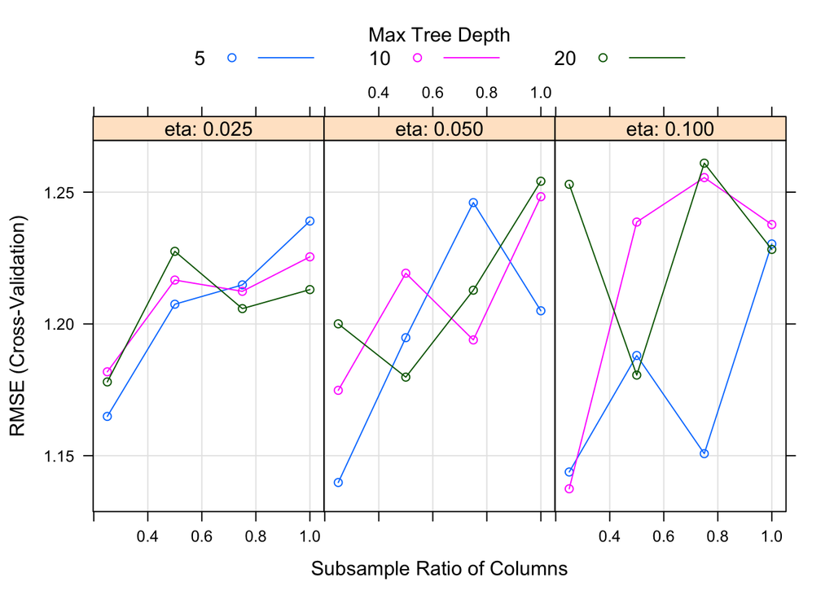

```
##  [1] 42.65972 41.77639 40.17952 39.85858 41.35170 40.07450 41.99403
##  [8] 41.97487 40.52615 38.58401 40.13391 41.76201 41.79659 41.65679
## [15] 39.39631 42.39115 40.34282 39.63641 40.58432 38.59756 39.21562
## [22] 40.93733 39.04482 38.47064 41.98007 40.01045 38.90347 38.75865
## [29] 38.92192 38.37058 38.20831 40.22436
```

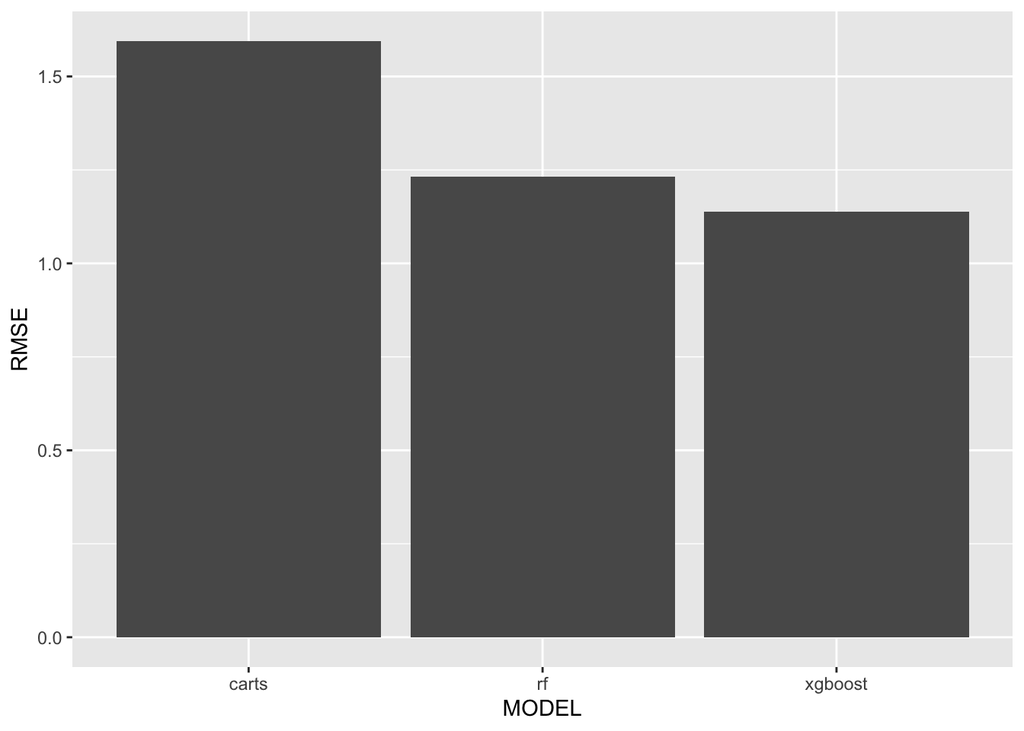

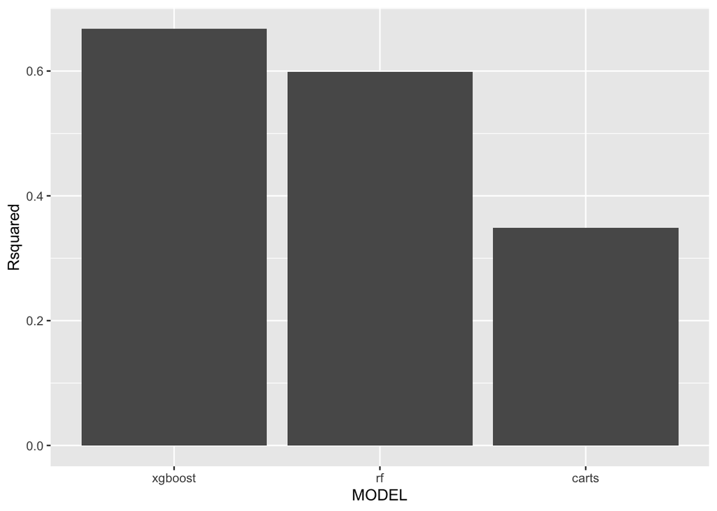

#### (a) Which tree-based regression model gives the optimal resampling and test set performance?

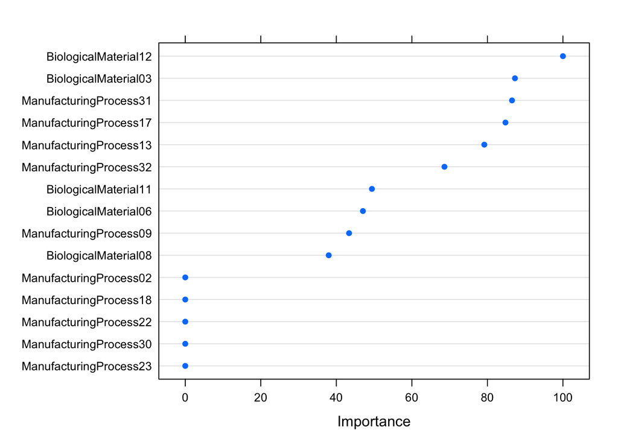

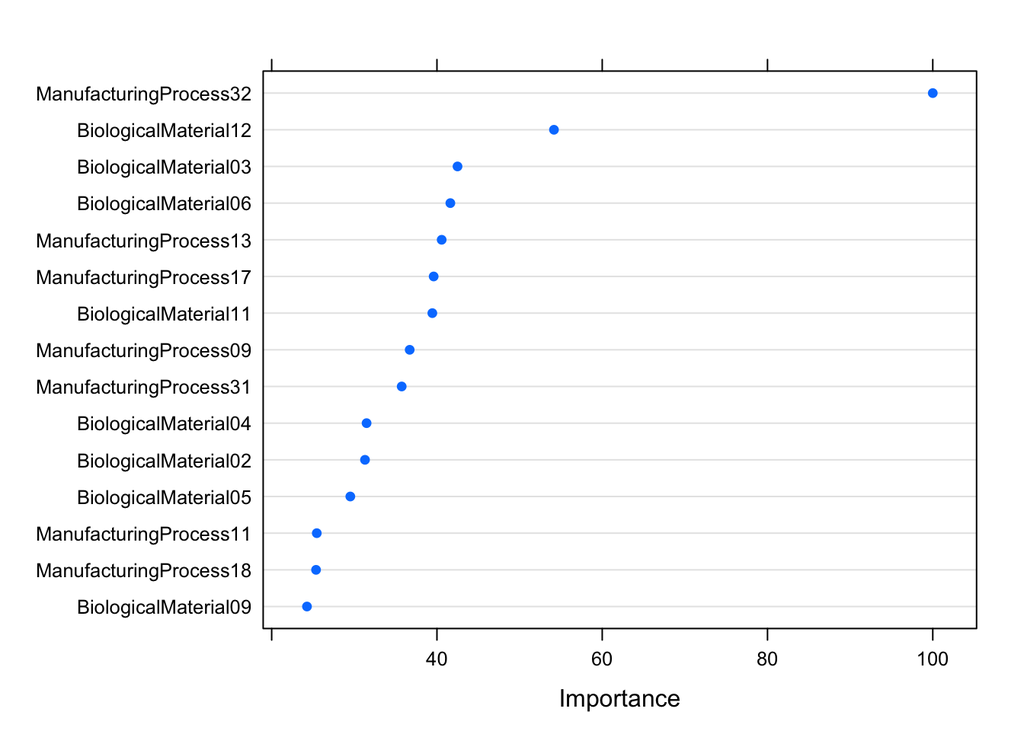

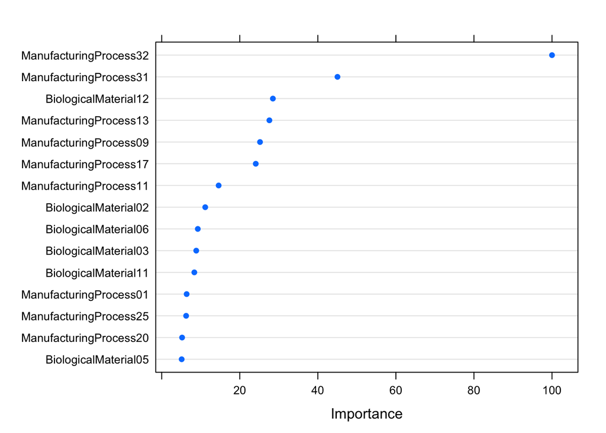

#### (b) Which predictors are most important in the optimal tree-based regression model? Do either the biological or process variables dominate the list? How do the top 10 important predictors compare to the top 10 predictors from the optimal linear and nonlinear models?

The most important predictors in the gradient boosting model are . . .

```
1. ManufacturingProcess32
2. ManufacturingProcess31
3. BiologicalMaterial12
4. ManufacturingProcess13
5. ManufacturingProcess09
```

[figure not shown]

#### (c) Plot the optimal single tree with the distribution of Yield in the terminal nodes. Does this view of the data provide additional knowledge about the biological or process predictors and their relationship with Yield?

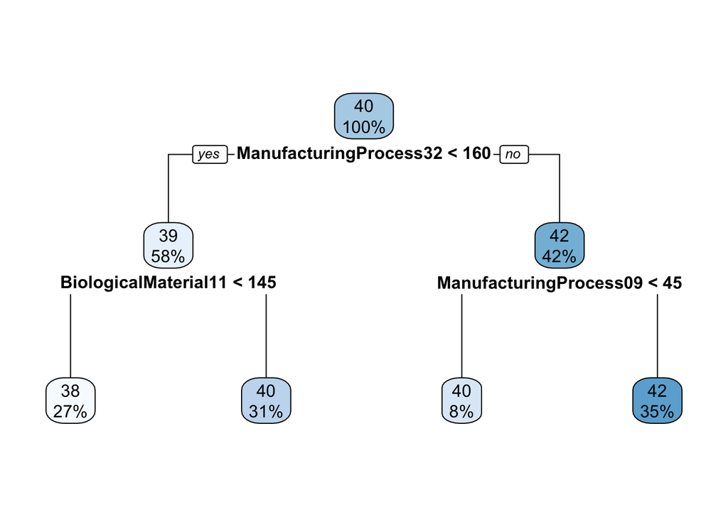